# Download and plot worldclim scenario data tmax

Kami Makabe

5/20/2021

### Load required libraries

If using r for the first time, you need to install the respective packages fisrt. The package names as similar to the libraries.

```r
library(raster)
library(magrittr)
library(rnaturalearth)
library(dplyr)
library(reshape)
library(ggplot2)
library(ggeasy)
library(stringr)
```

### Prepare your data

We will need to manually download our scenario data from [worldclim](https://worldclim.org/data/cmip6/cmip6climate.html), and store it locally. Alternatively, use direct download for example ‘ssp126_40url<- “https://biogeo.ucdavis.edu/data/worldclim/v2.1/fut/2.5m/wc2.1_2.5m_prec_BCC-CSM2-MR_ssp126_2021-2040.zip” download.file(ssp126_40url, destfile=“wc2.1_2.5m_prec_BCC-CSM2-MR_ssp126_2021-2040.zip”) unzip(“wc2.1_2.5m_prec_BCC-CSM2-MR_ssp126_2021-2040.zip”)’

Set the path to your downloaded files

```r
path126<-"C:/Workspace/RMardown_NAPS/Open-NAPs-Data/opennaps/WC_Fut_data/tmax126"
path245<-"C:/Workspace/RMardown_NAPS/Open-NAPs-Data/opennaps/WC_Fut_data/tmax245"
path370<-"C:/Workspace/RMardown_NAPS/Open-NAPs-Data/opennaps/WC_Fut_data/tmax370"
path585<-"C:/Workspace/RMardown_NAPS/Open-NAPs-Data/opennaps/WC_Fut_data/tmax585"
```

### Import files into r

Then load the files into your r environment. As a tip, since we already know our data is in .tif format, we will give r the instructions to only load files with the .tif extension. This works well, incase you use the directory for other file types.

```r
tx126_tif_only<-list.files(path126,full.names = TRUE, pattern = ".tif$")
tx245_tif_only<-list.files(path245,full.names = TRUE, pattern = ".tif$")
tx370_tif_only<-list.files(path370,full.names = TRUE, pattern = ".tif$")
tx585_tif_only<-list.files(path585,full.names = TRUE, pattern = ".tif$")
```

Each of the downloads has multiple files in it and this step will pile them together into one layer, also known as a rasterstack

```r
ssp126_stack<-stack(tx126_tif_only)
ssp245_stack<-stack(tx245_tif_only)
ssp370_stack<-stack(tx370_tif_only)
ssp585_stack<-stack(tx585_tif_only)
```

### Subset your data

```r
ssp126malawi<-crop(ssp126_stack,extent(malawi)) ## here you can use your shapefile from previous step or get the bounding coordinates from any map service and enter them in the order (west, east, south, north)
ssp126malawim<-mask(ssp126malawi,malawi)
#plot(ssp245malawim)  # remove the '#' sign to plot the individual stacked .tifs
ssp245malawi<-crop(ssp245_stack,extent(malawi))
ssp245malawim<-mask(ssp245malawi,malawi)

ssp370malawi<-crop(ssp370_stack,extent(malawi))
ssp370malawim<-mask(ssp370malawi,malawi)

ssp585malawi<-crop(ssp585_stack,extent(malawi))
ssp585malawim<-mask(ssp585malawi,malawi)
```

### Convert subset raster to data frame

Convert the subset data into data frame format using the function ‘as.data.frame’ and the ‘melt’ function to convert our data frame from a wide table to a long table format

```r
ssp126df<-as.data.frame(ssp126malawim, xy=TRUE, na.rm=TRUE, stringAsFactors=TRUE)%>%
  melt(id.vars=c('x','y'))
ssp245df<-as.data.frame(ssp245malawim, xy=TRUE, na.rm=TRUE, stringAsFactors=TRUE)%>%
  melt(id.vars=c('x','y'))
ssp370df<-as.data.frame(ssp370malawim, xy=TRUE, na.rm=TRUE, stringAsFactors=TRUE)%>%
  melt(id.vars=c('x','y'))
ssp585df<-as.data.frame(ssp585malawim, xy=TRUE, na.rm=TRUE, stringAsFactors=TRUE)%>%
  melt(id.vars=c('x','y'))
```

### Plot all the rasters from the df and the bounding geometry

[figure not shown]

```r
ggplot()+
  geom_raster(data=ssp126df, aes(x=x, y=y, fill=value))+
  facet_wrap(~variable)+
  geom_sf(fill='transparent', data = malawi)+
  scale_fill_gradient(low = 'yellow', high = 'red', name='°C')+
  xlab('Longitude')+ylab('Latitude')+ ggtitle('Monthly Maximum Temperature')+
  theme_bw()
```

### Select and plot single month

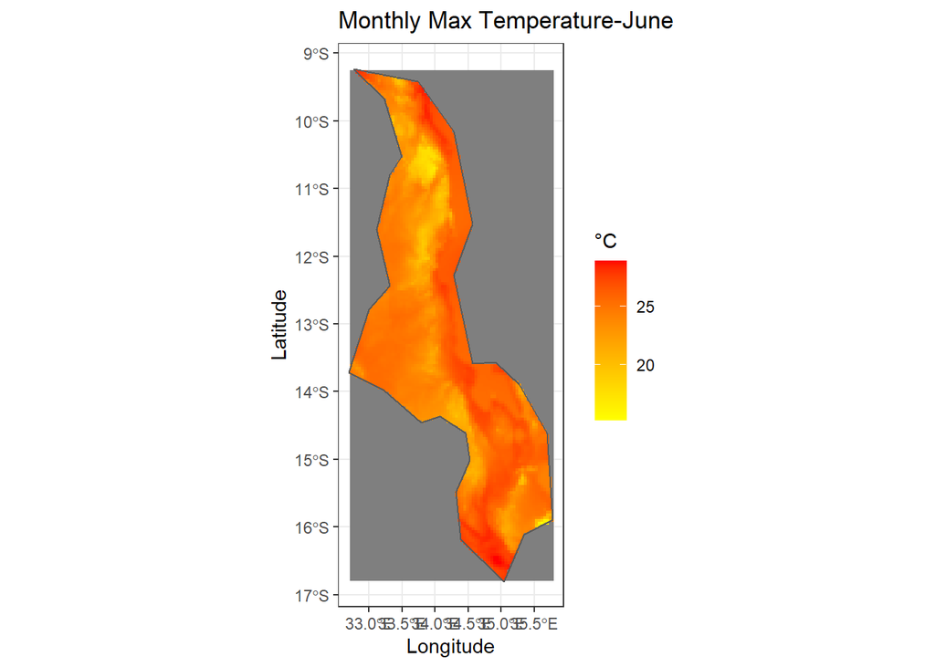

```r
xmonthdf<-as.data.frame(ssp126malawim[[06]], xy=TRUE, stringsAsFactors=FALSE)%>%
  melt(id.vars=c('x','y'))
ggplot()+
  geom_raster(data=xmonthdf, aes(x=x, y=y, fill=value))+
  xlab('Longitude')+ylab('Latitude')+
  geom_sf(fill='transparent', data = malawi)+
  scale_fill_gradient(low = 'yellow', high = 'red', name='°C')+
  ggtitle('Monthly Max Temperature-June')+
  theme_bw()
```

### Add column ‘Trend’ to dataframes

The next step would be to combine the 4 dataframes into one so that we can create plots easily. But since the data variables are identical, with no column to distinguish them, we will add a column called ‘Trend’ to each and populate it with respective values. Then combine the 4 dataframes using the base function ‘rbind’.

```r
Trend<-'ssp126'
ssp126df<-cbind(ssp126df,Trend)
Trend<-'ssp245'
ssp245df<-cbind(ssp245df,Trend)
Trend<-'ssp370'
ssp370df<-cbind(ssp370df,Trend)
Trend<-'ssp585'
ssp585df<-cbind(ssp585df,Trend)

tmax<-rbind(ssp126df,ssp245df,ssp370df,ssp585df)
```

### Add year and month columns to the data frame

Next, extract month and year values from the variable name and add them as separate columns

```r
Year<-substr(tmax$variable,36,44)
Month<-as.numeric(substr(tmax$variable,46,47))
tmax<-cbind(tmax, Month, Year)
```

Rename column ‘value’ to ‘tmax’

```r
colnames(tmax)[colnames(tmax)=="value"]<-"tmax"
```

### Plot monthly mean time series

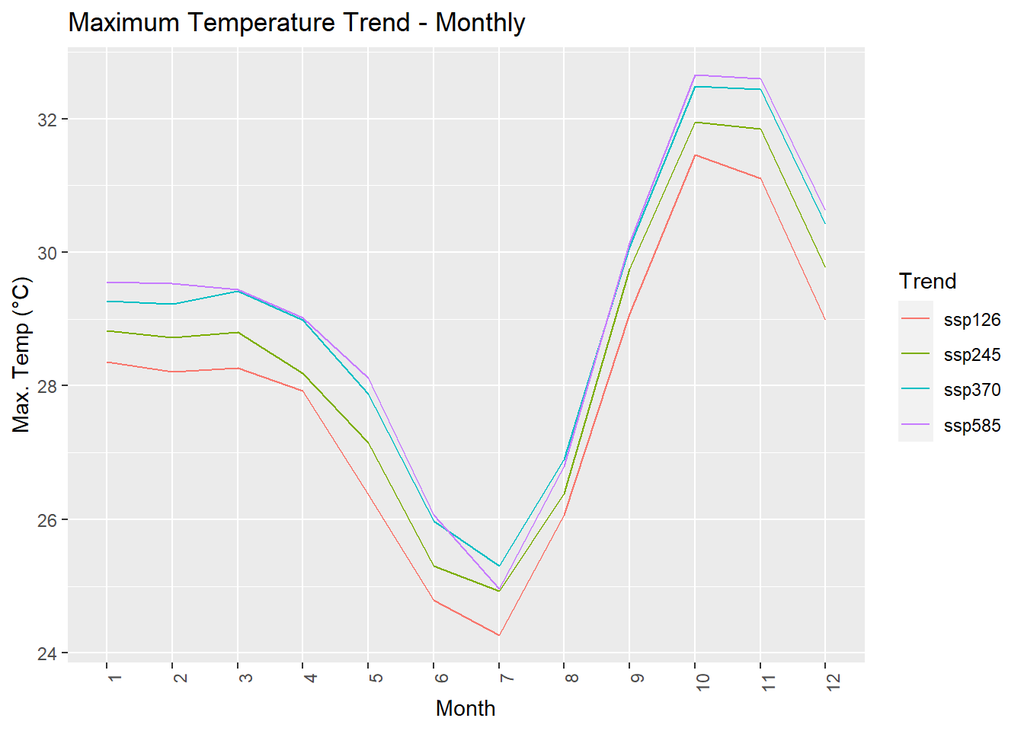

```r
txmon<-tmax%>%group_by(Trend, Month)%>%
  summarise(across(contains("tmax"), ~mean(tmax, na.rm=TRUE)))

txmon$Month<-factor(txmon$Month,levels = c('1','2','3','4','5','6','7','8','9','10','11','12'))

qplot(factor(Month),tmax, data = txmon, geom = "line", group = Trend, color= Trend) +
     #facet_grid(Trend ~ ., scale = "free") +
     scale_x_discrete() +
  ggtitle('Maximum Temperature Trend - Monthly')+
     easy_rotate_x_labels(angle = 90, side = "right")+
  ylab('Max. Temp (°C)')+ xlab('Month')
```

### Plot annual mean time series

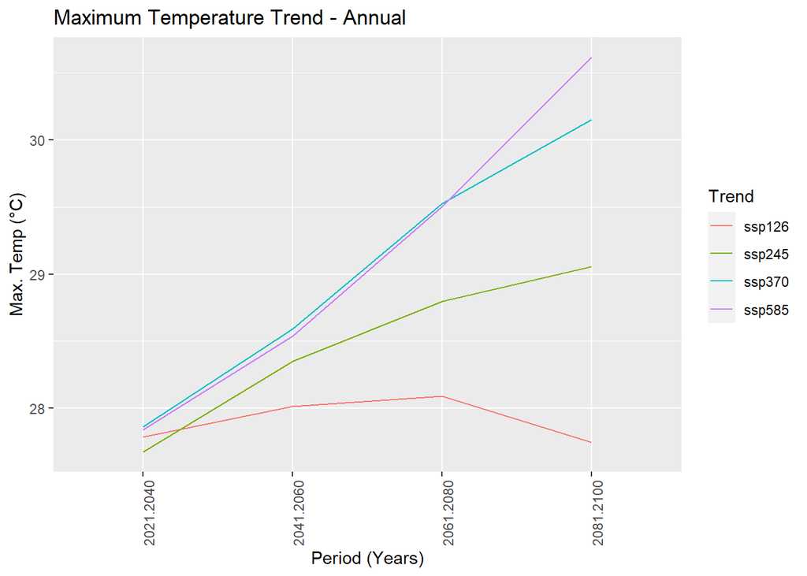

```r
txann<-tmax%>% group_by(Year, Trend)%>%
  summarise(across(contains("tmax"), ~mean(tmax)))
tstxann<- ts(txann$tmax,start = 2021,end=2100, frequency = 1)
#plot(tstxann)

qplot(Year,tmax, data = txann, geom = "line", group = Trend, color= Trend) +
     #facet_grid(Trend ~ ., scale = "free") +
     scale_x_discrete() +
  ggtitle('Maximum Temperature Trend - Annual')+
     easy_rotate_x_labels(angle = 90, side = "right")+
  ylab('Max. Temp (°C)')+ xlab('Period (Years)')
```

```r
#plotly::ggplotly(myplot)
```